# 분포함수

Seoncheol Park

1/31/2020

## 확률변수의 분포함수

확률론에서 가장 중요한 개념 중의 하나가 확률변수 $X$의 분포함수이다.

**Definition 1 (분포함수)** 확률변수 $X$의 분포함수는 $F(x) = P\{\omega: X(\omega)\leq x\}$, $x\in\mathbb{R}$이다.

**Proposition 1 (분포함수의 성질들)** A distribution function $F(x)$ satisfies the following conditions.

1. $F(x)$ is monotone increasing.
2. $F(x)$ is right-continuous at each $x$.
3. $\lim_{n\rightarrow -\infty}F(x) = 0$ and $\lim_{n\rightarrow \infty}F(x)=1$.

*Proof.* 1. Monotonicity는 분포함수의 정의로부터 바로 나온다.

2. Right-continuity를 보이려면 $x_{n}\downarrow x$일 때 $F(x_n)\rightarrow F(x)$임을 보이는 것으로 충분다. $E_{n}= \{\omega: -\infty < X(\omega) \leq x_n \} \downarrow E = \{ \omega : -\infty < X(\omega) \leq x\}$임을 상기하자. 확률의 continuity property에 의해 $P(E_n)\rightarrow P(E)$이다. 그러나 $P(E_n)=F(x_n)$이고 $P(E) = F(x)$이기 때문에 $F_{n}(x) \rightarrow F(x)$가 되어 $F(x)$가 $x$에서 right-continuous하다.
3. $\pm \infty$에서의 극한 움직임을 보려면 $x_{n}\downarrow -\infty$일 때 $F(x_n)\rightarrow 0$임을, $x_{n}\uparrow\infty$이면 $F(x_n)\rightarrow 1$임을 보이면 된다. $x_n \rightarrow -\infty$임에 따라 $\{\omega : X(\omega)\in (-\infty, x_n]\}\downarrow \emptyset$이고 $x_{n}\rightarrow \infty$일 때에는 $\uparrow \{ \omega: -\infty < X(\omega) < \infty \}$임을 관찰한다. 확률의 continuity property에 의해 $F(x_n)=P(-\infty < X(\omega)\leq x_n)\rightarrow P(\emptyset) = 0$ as $x_n \rightarrow -\infty$이고 $x_n\rightarrow\infty$일 때에는 $\rightarrow P(-\infty < X<\infty)=1$이 된다.

*Remark.* 위 proposition의 역도 참이다. 즉 위의 세 가지 조건을 만족하는 함수는 확률공간 $(\Omega, \mathcal{F}, P)$에서 정의된 확률변수 $X$의 분포함수가 된다.

$F(x)$가 monotone이라는 뜻은 left, right-hand limit $\lim_{x\uparrow x_{0}}F(x)$ 그리고 $\lim_{x\downarrow x_{0}}F(x)$가 모두 존재한다는 의미다. 그래서 $F(x)$는 pathodological behavior, 예를 들면 $x\rightarrow 0$일 때 $\sin (\frac{1}{x})$가 그런 것처럼 행동하는 함수는 exhibit할 수 없다.

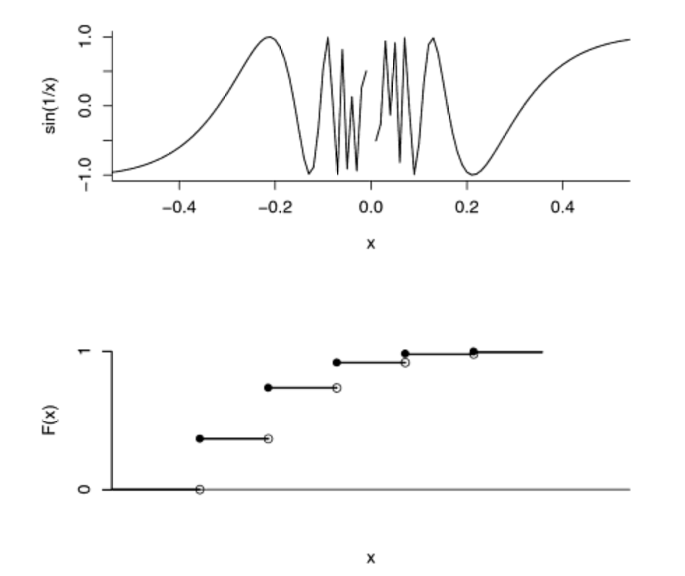

Figure 1: (top) Since function exhibits bizarre behavior with no limit at x is near 0. F(x) cannot exhibit such behavior. (bottom) The only type of discontinuity of F(X) is a jump.

이 때에는 두 가가지 가능성밖에 없다. (i) left, right limit가 서로 일치하거나, (ii) 불일치하거나. 만약 둘이 일치한다면, $F(x)$는 $x_0$에서 연속일 것이다. 만약 일치하지 않는다면, $F(x)$는 $x_0$에서 jump discontinuity를 갖을 것이다. 분포함수는 countablely many infinite jump를 갖을 수 있다. 이는 다음의 따름정리에서 드러난다.

**Proposition 2 (분포함수의 불연속성)** 분포함수 $F$가 $x$에서 연속이라는 것은 $P(X=x)=0$이라는 것과 동치다. 더 나아가 확률변수 $X$의 분포함수 $F(X)$의 불연속점들의 collection은 countable이다.

*Proof.* 1. $P(X=x) = P(X\leq x) - P(X<x) = F(x) - P(\cup_{n}\{ X\leq x_n\})$, where $x_n$은 $x_n \uparrow x$를 만족하는 any sequence가 성립함을 상기하자. 확률의 continuity 성질과 $E_n =\{\omega: X(\omega)\leq x_n\}\uparrow E = \{\omega: X(\omega)<x \}$ 성질에 의해, $P(X=x)=0$이라는 것은 $F(x) - _{n}F(x_n) = 0 $ for every sequence $x_n \uparrow x$임과 같다. 즉 $P(X=x)=0$은 $F$가 $x$에서 left-continuous임과 동치다. 그러나 분포함수의 right-continuous 성질에 의해 $P(X=x)=0$임은 $F$가 $x$에서 continuous함과 동치이다.

2. $F$의 discontinuous한 부분이 countable임을 보이려면, 먼저 $F(x)$는 0과 1 사이의 값을 가지게 되므로 size $\frac{1}{n}$인 jump들이 $n$개 이상 존재할 수 없게 된다. 그래서 size가 $\frac{1}{n}$ 또는 그보다 큰 jump들의 집합은 countable이다. Set of all jump들은 $\cup_{n} \{ \text{jumps of size $\frac{1}{n}$ or more} \}$ countable set들의 countable union이므로 countable이 된다.

앞서 $\mathcal{F}$에서의 확률측도 $P$는 $\mathbb{R}$에서의 Borel 집합들 $\mathcal{B}$에서의 확률측도 $P'$를 $P'(B) = P\{\omega: X(\omega)\in B \}$로 정의할 수 있음을 보였다. 이제 $\mathcal{F}$에서의 $P$를 계산하나 $\mathcal{B}$에서 $P'$를 계산하나 결과는 같다. $B=(-\infty, x]$일 때 $P'(B)=F(x)$가 된다. 우리가 $F(x)$를 알면 $P'(B)=P\{ \omega : X(\omega)\in B \}$ for each Borel set $B$가 되어 다음의 결과를 보여준다.

**Proposition 3 (Probability measure induced by X is determined by its distribution function)** The probability measure $P'(B)$ on $(\mathbb{R}, \mathcal{B})$ induced by a random variable $X$ is uniquely determined by the distribution function $F(x)$ of $X$.

*Proof.* The distribution function defines $P'(C)$ for all sets $C$ of the form $(-\infty, a], a\in\mathbb{R}$. For $C$ of the form $(a,b]$, $P'(C)=F(b)-F(a)$, so $P'(C)$ is also determined by $F$. For $C$ of the form $(b,\infty)$, $P'(C)=1-F(b)$ is determined by $F$. By countable additivity of probability measures, $P(C)$ is determined by $F$ for all sets $C$ in the field $\mathcal{F}_{0}$ of unions of a finite number of disjoint sets of the form $(a,b]$, $(-\infty, a]$, or $(b,\infty)$. But $\mathcal{F}_{0}$ generates the Borel $\sigma$-field, so (Probability measures agreeing on a field agree on the generated $\sigma$-field) shows that the probability $P'(B)$ of any Borel set $B$ is uniquely determined from the probabilities of sets $C\in\mathcal{F}_{0}$, which we have shown are determined from $F$. This shows that the distribution funtion $F(x)$ of $X$ completely and uniquely determines the probability measure $P'$ induced by $X$.

**Proposition 4 (Continuous distribution functions are uniformly continuous)** If $F(x)$ is a distribution function that is continuous for all $x\in \mathbb{R}$, then $F$ is uniformly continuous.

*Proof.* $\epsilon>0$이 주어졌다고 가정해보자. 그러면 우리는 $|y-x|<\delta \Rightarrow |F(y)-F(x)|<\epsilon$을 만족하는 $\delta$를 찾아야 한다. $P(|X|\geq A) <\frac{\epsilon}{2}$를 만족하는 양수 $A$를 찾자. $[-A,A]$에서 $F$는 uniformly continuous이고 따라서 $-A\leq x\leq A$, $-A\leq y \leq A$ 그리고 $|y-x|<\delta$일 때 $|F(y)-F(x)|<\frac{\epsilon}{2}$를 만족하는 $\delta$가 존재한다. 우리는 이러한 $\delta$가 구간 $[-A,A]$가 아닌 임의의 $x\in \mathbb{R}$, $y\in\mathbb{R}$에서도 작동함을 보여야 한다. WLOG, $\delta < 2A$라고 두자. 왜냐면 우리는 항상 $\delta$를 감소시킬 것이기 때문에 이렇게 가정해도 된다.

$x\in\mathbb{R}$, $y\in\mathbb{R}$을 $|y-x|<\delta$를 만족하는 어떤 실수라고 하자. 그리고 WLOG, $x<y$라고 둔다. 그러면 $x$와 $y$가 모두 $-A$와 $A$ 사이에 있을 때 $|F(y)-F(x)|<\frac{\epsilon}{2}<\epsilon$가 된다. 한편, 만약 $x,y$가 모두 $-A$보다 작다면 다음이 성립한다.

$$|F(y)-F(x)| \leq F(y)+ F(x) <\frac{\epsilon}{2} + \frac{\epsilon}{2} = \epsilon.$$

비슷한 논리를 $x,y$가 모두 $A$보다 클 때에도 적용할 수 있다. 만약 $x<-A$, $-A\leq y \leq A$인 경우에는 다음과 같이 된다.

$$\begin{align}
|F(y)-F(x)| &= |F(y) - F(-A) + F(-A) -F(x)|\\
&\leq |F(y)-F(-A)|+|F(-A) -F(x)|\\
&< \frac{\epsilon}{2} + \frac{\epsilon}{2} = \epsilon.
\end{align}$$

비슷한 논리를 $-A\leq x \leq A$ 그리고 $y>A$일 때에도 적용할 수 있다. 우리가 $\delta<2A$로 잡았기 때문에 $x<-A, y>A$인 경우는 고려 안해도 된다. 따라서 이것으로 $F$가 uniformly continuous임을 증명했다.

## 확률벡터의 분포함수

**Definition 2 (확률벡터의 분포함수)** $(X_1, \ldots, X_k)$의 다변량 분포함수는 $P\{\omega: X_{1}(\omega) \leq x_1, \ldots, X_{k}(\omega) \leq x_k \}$로 정의된다.

**Example 1** $(\Omega, \mathcal{F}, P)=([0,1], \mathcal{B}_{[0,1]}, \mu_{L})$이라고 두고 $X_{1}(\omega) = I(\omega \in [\frac{1}{2}, \frac{3}{4}])$ 그리고 $X_{2}(\omega) = \omega^{2}$으로 둔다. $(X_1,X_2)$의 joint distribution $F(x_1, x_2)$를 생각해보자. 만약 $x_1<0$이면 $X_{1}$이 음수를 갖지 않기 때문에 $F(x_1, x_2)=0$이 된다. 만약 $0\leq x_{1} <1$이면 $X_{1} \leq x_1$은 $X_{1} = 0$이라는 것이 되고 이것은 $\omega [0,\frac{1}{2})\cup (\frac{3}{4},1]$인 것과 같다. 또한 $X_{2}\leq x_2$는 $x_2<0$인 경우에는 불가능하다. 만약 $x_2\geq 0$이면, $X_{2}\leq x_2$라는 것은 $\omega \in [0, \min (1, \sqrt{x_2})]$라는 것과 같다. 따라서 만약 $0\leq x_1 <1$이고 $x_2\geq 0$이면

$$\begin{equation}
\{X_1(\omega)\leq x_1 \}\cap \{X_{2}(\omega)\leq x_2\} = \{ \omega \in ( [0,\frac{1}{2})\cup (\frac{3}{4},1] ) \cap [0, \sqrt{x_2}] \}
\tag{1}
\end{equation}$$

이다. 위 식의 오른쪽 부분은 다음과 같다.

$$\begin{cases}
[0,\sqrt{x_2}] & \text{ if } 0 \leq x_2 < \frac{1}{4}\\
[0,\frac{1}{2}) & \text{ if } \frac{1}{4} \leq x_2 \leq \frac{9}{16}\\
[0,\frac{1}{2}) \cup (\frac{3}{4}, \sqrt{x_2}] & \text{ if } \frac{9}{16}<x_2 \leq 1.
\end{cases}$$

이 세 가지 집합의 르베그 측도는 $\sqrt{x_2}, \frac{1}{2}, \frac{1}{2}+\sqrt{x_2} -\frac{3}{4} = \sqrt{x_2} - \frac{1}{4}$이다. 만약 $x_1 \geq 1$이라면 식 (1) 는 $X_{2}\leq x_2$이고 $0\leq x_2 <\infty$일 때 르베그 측도로 $\min (1,\sqrt{x_2})$를 갖는다. 그러므로 $(X_1, X_2)$의 분포함수는 다음과 같다.

$$\begin{cases}
0 & \text{ if } x_{1}<0 \text{ or } x_2 <0\\
\sqrt{x_2} & \text{ if } 0\leq x_1 < 1, 0 \leq x_2 <\frac{1}{4}\\
\frac{1}{2} & \text{ if } 0 \leq x_1 < 1 , \frac{1}{4}\leq x_2 \leq \frac{9}{16}\\
\min(1,\sqrt{x_2}) -\frac{1}{4} & \text{ if } 0 \leq x_1 < 1, \frac{9}{16}<x_2 < \infty\\
\min(1,\sqrt{x_2}) & \text{ if } 1 \leq x_1 < \infty, 0 \leq x_2 <\infty.
\end{cases}$$

The probability measure $P'$ on $\mathbb{R}^{k}$ induced by $(X_1, \ldots, X_k)$is completely determined from its multivariate distribution function.

**Proposition 5 (Probability measure induced by random vector X is determined by its distribution function)** The probability measure $P'(B)$ on $(\mathbb{R}^{k}, \mathcal{B}^{k})$ induced by a random vector $\mathbf{X}$ is uniquely determined by the distribution function $F(\mathbf{x})$ of $\mathbf{X}$.

1차원에서 분포함수는 right-continuous라고 했는데 다변량 분포함수 $F(x_1, \ldots, x_k)$에 대해 대응되는 개념으로 **continuous from above**라는 개념이 있다 이 개념은 $i=1,\ldots, k$일 때 $x_{in}$이 $n\rightarrow\infty$일 때 $x_{i}$에 접근함에 따라 $F(x_{1n},\ldots, x_{kn})\rightarrow F(x_1, \ldots, x_k)$임을 의미한다.

**Proposition 6 (right-continuity의 다변량 개념)** 다변량 분포함수는 **continuous from above**이다.

*Proof.* $x_{in}\downarrow x_{i}$일 때 $F(x_{1n},\ldots, x_{kn})\rightarrow F(x_1, \ldots , x_k)$임을 보이는 것으로 충분하다. 따라서 $x_{in}$을 decreasing sequence로 가정한다. 그러면 $E_{n}= (-\infty, x_{in}]\times (-\infty, x_{2n}]\times \ldots \times (-\infty, x_{kn}]$은 $n\rightarrow\infty$임에 따라 $E=(-\infty,x_1]\times (-\infty,x_2]\times \ldots \times (-\infty,x_{k}]$로 가게 된다. 따라서 확률의 continuity property에 따라 결과를 얻게 된다.

$$f(x_1, x_2)=
\begin{cases}
+1 & \text{ if } x_1 x_2 >0 \text{ or } (x_1, x_2) = (0,0)\\
-1 & \text{ if } x_1 x_2 <0.
\end{cases}$$

그렇다면 $f$는 (0,0)에서 continuous from above and below이나 $(0,0)$의 북서쪽 $(x_1 <0, x_2 >0)$, 북동쪽 $(x_1>0, x_2>0)$에서 $(0,0)$으로 접근할 때 같은 극한값을 갖지 않으므로 $f(x_1, x_2)$는 원점에서 연속이 아니다.

앞선 예제의 $f$와 다변량 분포함수 $F$으로 차이는 $F$가 each argument에서 increasing이냐 아니냐의 차이다. 이 성질이 앞선 예제와 같은 예외사항들을 제거해 준다.

**Proposition 7 (Continuous from below implies continuous for distribution functions)** 다변량 분포함수가 $(x_1,\ldots, x_k)$에서 연속임과 동치조건은 그것인 $(x_1,\ldots, x_k)$에서 continuous from below인 것이다.

*Proof.* 앞선 proposition으로부터 $F$가 continuous from above임을 알기 때문에 multivariate d.f. continuity from above and below is equivalent to continuity임을 보이면 된다. 물론 continuity는 continuity from above, below를 모두 포함하기 때문에 우리는 continuity from above, below를 만족할 때 실제로 continuity도 성립하지는지만 보면 되는 것이다.

$F$가 continuity from above, below를 만족한다고 가정하자. 만약 $F$가 연속이 아리나면 $\epsilon>0$과 $\mathbf{x}$로 수렴하는 수열 $\mathbf{x}_{n} = (x_{1n},\ldots, x_{kn})$이 존재해 $F(\mathbf{x}_{n})\leq F(\mathbf{x})-\epsilon$ for infinitely many $n$ 이거나 $F(\mathbf{x}_{n})\geq F(\mathbf{x}) + \epsilon$ for infinitely many $n$일 것이다.

1. $F(\mathbf{x}_{n})\leq F(\mathbf{x})-\epsilon$ for infinitely many $n$ 이라면 $F(\mathbf{x}_{n}')\leq F(\mathbf{x}) - \epsilon$ for infinitely many $n$, where each component of $\mathbf{x}_{n}'$ is the minimum of the corresponding components of $\mathbf{x}_{n}$ and $\mathbf{x}$일 것이다. (그림 참고)
2. 이와 유사하게 $F(\mathbf{x}_{n})\geq F(\mathbf{x}) + \epsilon$ for infinitely many $n$인 경우도 $F(\mathbf{x}_{n}'')\geq F(\mathbf{x}) + \epsilon$ for infinitely man $n$, where each component of $\mathbf{x}_{n}''$ is the maximum of the corresponding components of $\mathbf{x}_{n}$ and $\mathbf{x}$일 것이다.

그러므로 만약 continuity를 위반하는 어떠한 sequence가 존재한다면, continuity from below or continuity from above를 위반하는 seqeunce 또한 존재할 것이다.

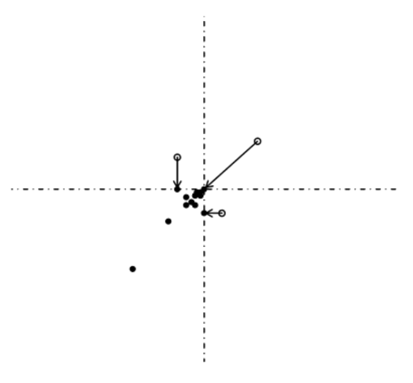

Figure 2: 앞선 증명 관련 그림.

**Proposition 8 (Characterization of continuity of a multivariate d.f. at a point)** Let $F$ be a multivariate distribution function. For a given $(x_1, \ldots, x_k)$, let $p_{i} = P(X_{1} \leq x_1, \ldots, X_{i-1}\leq x_{i-1}, X_{i}=x_i, X_{i+1}\leq x_{i+1}, \ldots , X_{k} \leq x_{k})$. Then $F$ is continuous at $(x_1, \ldots, x_{k})$ if and only if $p_{i}=0$ for all $i=1,\ldots, k$.

*Proof.* Let $p=P[(\cap_{i}\{ X_{i} \leq x_i \}) \cap (\cup_{i} \{ X_i = x-i \})]$. Then $p=P(\cap_{i} \{ X_{i}\leq x_i \}) - P(\cap_{i} \{ X_{i}<x_i \}) = F(x_1, \ldots, x_k) - \lim_{x_{1n}\rightarrow x_{1}^{-},\ldots, x_{kn}\rightarrow x_{k}^{-}}F(x_{1n},\ldots, x_{kn})$. Therefore $p=0$ if and only if $F$ is continuous from below. 앞선 따름정리에 의해 $F$가 연속인 필요충분조건은 $p=0$인 것이다. 그러므로, $p=0$인 것이 $p_{1} =0, p_{2} = 0, \ldots, p_{k}=0$임을 보이기만 하면 된다. $p=P(\cup_{i} \{ X_{1} \leq x_1, \ldots, X_{i-1}\leq x_{i-1}, X_{i}=x_{i}, X_{i+1}\leq x_{i+1}, \ldots, X_{k}\leq x_{k} \})$이므로, countable subadditivity는 $p\leq \sum_{i} p_{i}$임을 보장한다. 그러므로

$$p_{i}\leq p\leq \sum_{i=1}^{k}p_{i}, \qquad{i=1,\ldots, k}$$

이며 이것으로부터 $p=0$이 $p_i=0$ for all $i=1,ldots, k$임과 동치임을 보였다.

**Corollary 1 (연속의 충분조건)** $(x_1, \ldots, x_k)$에서 다변량 분포함수 $F$가 연속일 충분조건은 $i=1,\ldots, k$일 때 $P(X_i = x_i)=0$인 것이다.

*Proof.* 상술한 조건은 $P(X_1 \leq x_i, \ldots, X_{i-1}\leq x_{i-1}, X_{i}=x_{i}, X_{i+1}\leq x_{i+1},\ldots, X_{k}\leq x_k)=0$임을 내포한다. 여기서 앞선 따름정리를 적용하면 된다.

We call the line $x_i = x$ an axis line of discontinuity of a multivariate d.f. $F$ if $F$ is discontinuous at $(x_1, \ldots, x_{i}= x, \ldots, x_k)$ for one or more values of $x_1, \ldots, x_{i-1}, x_{i+1}, \ldots, x_{k}$. Let $\mathcal{L}_{i}$ denote the axis line of discontinuity. 그렇다면 앞선 따름정리는 다음을 내포한다.

**Proposition 9 (Countably many axis lines of discontinuity)** The collection $\cup_{i}\mathcal{L}_{i}$ of axis lines of discontinuity of a multivariate d.f. is countable.

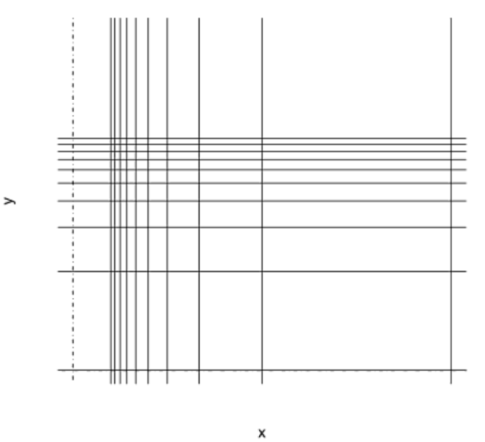

Figure 3: All of the discontinuities of a bivariate distribution function must lie on countably many horizontal/vertical lines.

그런데 주의해야 할 점은 앞서 말한 따름정리가 there are only countably many points of discontinuity of $F$임을 말하는 것이 아니다!!

예를 들면, $X_1$이 Bernoulli$(\frac{1}{2})$이고 $X_2$와 독립이라고 하자. $X_2$는 표준정규분포라고 하자. 그러면 $F(x_1, x_2) = \{ (\frac{1}{2})I(0\leq x_1 < 1) + I(x_1 \geq 1) \}\Phi(x_2)$이다. 그러면 $F$는 discontinuous at the uncountable many points $(0,x_2)$ for all $x_2\in\mathbb{R}$ and $(1,x_2)$ for all $x_2 \in \mathbb{R}$, though all points on discontinuity lie on only two lines $x_1 = 0$ and $x_1 = 1$이다.

다변량 분포에서 우리는 각각의 $X_i$에 대해 **marginal distribution function**을 얻을 수 있다. 예를 들면 $\mathbf{X}=(X_1, X_2)$가 분포함수 $F(x_1, x_2)$를 갖는다면 $X_1$에 대한 marginal distribution functions은 $P(X_1 \leq x_1) = P(X_1 \leq x_1, -\infty < X_2 <\infty) = \lim_{A\uparrow \infty}F(x_1, A)$이다. 비슷하게 만약 $\mathbf{X}=(X_1, \ldots, X_k)$일 경우 the joint distribution function for any subset of random variables can be obtained from the joint distribution function $F(x_1, \ldots, x_k)$ by setting the remaining $x$ values to $A$ and letting $A\uparrow \infty$. For example, the joint distribution function for $(X_1, X_2)$ is $\lim_{A\uparrow\infty}F(x_1, x_2,A,\ldots, A)$, and the marginal distribution for $X_1$ is $\lim_{A\uparrow \infty}F(x_1, A,\ldots, A)$.